# Reproducible Research: Peer Assessment 1

Melissa Berkheimer

output: html_document

## Abstract

This document examines the movement data of one individual at 5 minute increments between the period of October 1st and November 30th 2010.

### Retrieving data

The data was read into R from the file “activity.csv”. “activity.csv” contained 17568 observations and consisted of three variables: two intergers, steps and interval, and a factor, date, with 61 levels. The levels were saved as a vector and the class of the date variable was changed to character.

```r
setwd("D:/R files/Reproducible Research/prog 1")
dat <- read.csv("activity.csv", sep = ",")
datDate<- transform(dat, date = as.character(date))
dates <- levels(dat[,2])
```

To aid in analysis the stringr library was loaded.

```r
library(stringr)
```

## Total number of steps taken per a day

Steps were counted for a total of 61 days.

```r
        ##create empty data.frame
        stepsDay <-data.frame(matrix(vector(), 61, 2,
                dimnames=list(c(), c("Date", "Total steps"))),
                stringsAsFactors=F)

        ##loop through all dates
        for (i in 1:61){
                stepsDay[i,1] <- as.character(dates[i], format = "%Y-%m-%d")
                x <- datDate[which(datDate$date == dates[i]),1]
                stepsDay[i,2] <- sum(x, na.rm = T)
        }
```

The histogram below shows the frequency of the total number of steps taken per a day. The large 0 step value was attributted to days were the steps data values were missing or not recorded.

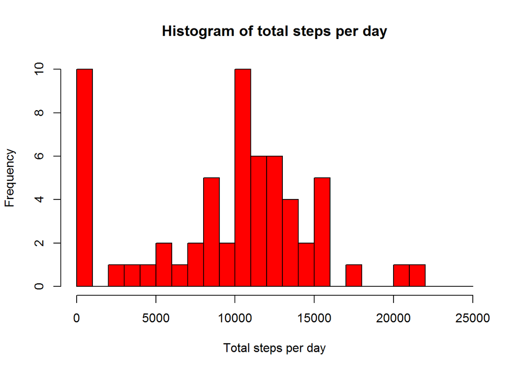

```r
        x <- seq(0, 25000, 1000)
        hist(stepsDay[,2],col = "red", breaks = x,
             main = "Histogram of total steps per day",
             xlab = "Total steps per day")
```

The median and mean total step counts were found to be:

```r
        medianSteps <- summary(stepsDay)[3,2]
        meanSteps <- summary(stepsDay)[4,2]
        medianSteps
```

```
## [1] "Median :10395  "
```

```r
        meanSteps
```

```
## [1] "Mean   : 9354  "
```

## Activity through out the day

Each day was split into a total of 288 five minute intervals. The activity across each time interval was averaged to show the user’s pattern of activity.

```r
##create empty data.frame
stepsTime <-data.frame(matrix(vector(), 288, 2,
                dimnames=list(c(), c("Time", "Average steps"))),
                stringsAsFactors=F)
j <- 0

##loop through all dates
for (i in seq(0, 2355, 5)){
        x1 <- as.character(i)
        x2 <- as.numeric(str_sub(x1,-2,-1))
        if (x2 < 60){
                j <- j + 1
                stepsTime[j,1] <- i
                y <- dat[which(dat$interval == as.integer(i)),1]
                stepsTime[j,2] <- sum(y, na.rm = T)/61
        }
}
```

The average number of steps taken was plotted against the time of day.

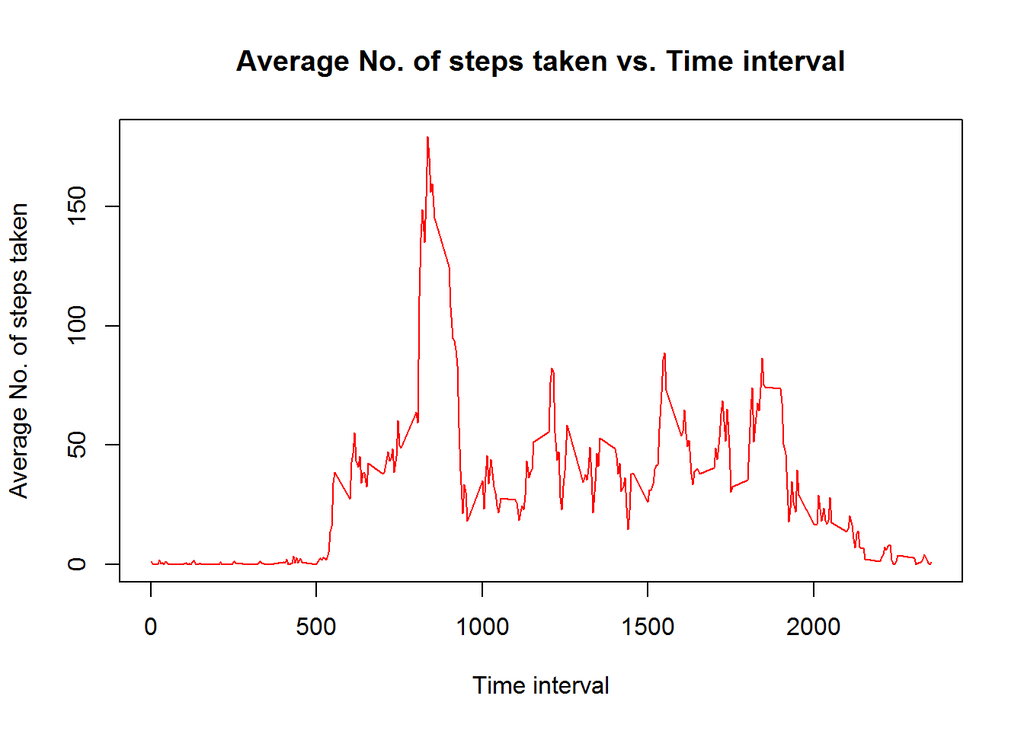

```r
##Create a time series plot of 5 minute intervals(x) and
        ##the avg. no. of steps taken avg.ed across all days(y)
        plot(x = stepsTime[,1], y = stepsTime[,2],
             type = "l", col = "red",
             main = "Average No. of steps taken vs. Time interval",
             ylab = "Average No. of steps taken",
             xlab = "Time interval")
```

```r
##Which of the 5 min intervals contains the maximum number of steps?
        maxSteps <- max(stepsTime[,2])
        maxTime <- stepsTime[which(stepsTime[,2] == maxSteps),1]
        ##maxSteps
        ##maxTime
```

The maximium number of steps was found to be 179.1311 at 835.

## Inputing missing values

The histogram above shows a large number of “0” step days. Several of these days can be attributted to missing data values. To give a more accurate snapshot of the user’s activity these values were approximated from the average step data of the affected time intervals.

```r
##find total no. missing values in dat, fill in w/ avg steps per interval
filledIn <- dat

missing <- 0
for (i in 1:17568){
        if (!complete.cases(dat[i,]) == T){
                missing <- missing + 1
                interval <- as.numeric(dat[i,3])
                filledIn[i,1] <- stepsTime[which(stepsTime[,1] == interval),2]
        }
}
filledIn<- transform(filledIn, date = as.character(date))
```

The number of missing values was found to be 2304.

The new data was then used to create a new histogram, shown below. Time intervals that reported “0” instead of Na were left unadulterated, resulting in a 2 “0” step days.

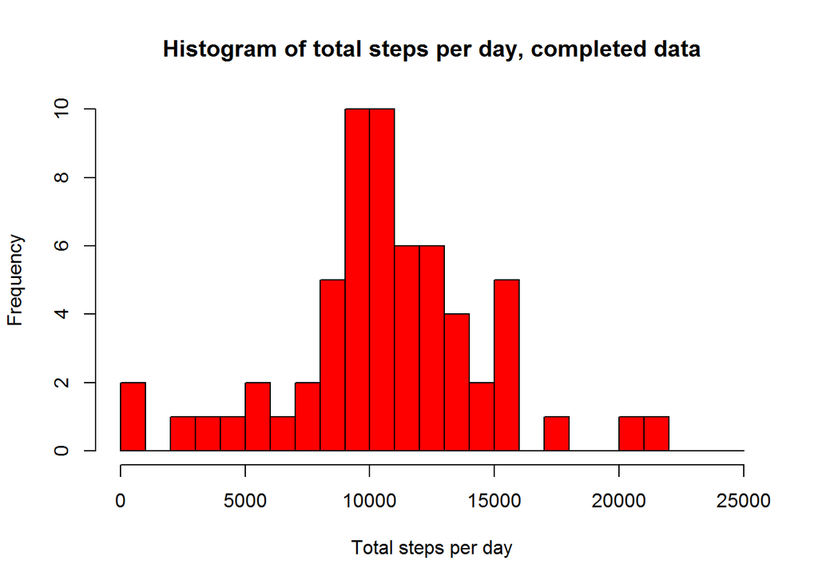

```r
##make a new histogram of total steps/day

##create empty data.frame
stepsDay2 <-data.frame(matrix(vector(), 61, 2,
                dimnames=list(c(), c("Date", "Total steps"))),
                stringsAsFactors=F)

##loop through all dates
for (i in 1:61){
        stepsDay2[i,1] <- as.character(dates[i], format = "%Y-%m-%d")
        x <- filledIn[which(filledIn$date == dates[i]),1]
        stepsDay2[i,2] <- sum(x, na.rm = T)
}

##plot histogram
x <- seq(0, 25000, 1000)
hist(stepsDay2[,2],col = "red", breaks = x,
     main = "Histogram of total steps per day, completed data",
     xlab = "Total steps per day")
```

The new median and mean were found to be:

```r
## return mean, median no. of steps/day
summary(stepsDay2)[3,2]
```

```
## [1] "Median :10395  "
```

```r
summary(stepsDay2)[4,2]
```

```
## [1] "Mean   :10581  "
```

## Weekday vs. weekend activity

```r
##factor filledin via weekend vs weekdays
filledInDate <- transform(filledIn, date = as.Date(date))
dayWeek <- weekdays(filledInDate$date, abbreviate = F)
filledIn2 <- cbind(filledIn,dayWeek)

##split filledIn2

filledIn4 <- split(filledIn2, filledIn2$dayWeek)

Saturday <- filledIn4$Saturday
Sunday <- filledIn4$Sunday
Monday <- filledIn4$Monday
Tuesday <- filledIn4$Tuesday
Wednesday <- filledIn4$Wednesday
Thursday <- filledIn4$Thursday
Friday <- filledIn4$Friday
```

```r
## Weekend
## create weekend df

weekend <-data.frame(matrix(vector(), 288, 2,
                dimnames=list(c(), c("Time", "Average steps"))),
                stringsAsFactors=F)

##loop through Saturdays, Sundays
##Saturday
j <- 0
for (i in seq(0, 2355, 5)){
        x1 <- as.character(i)
        x2 <- as.numeric(str_sub(x1,-2,-1))
        if (x2 < 60){
                j <- j + 1
                weekend[j,1] <- i
                y <- Saturday[which(Saturday$interval == as.integer(i)),1]
                a <- sum(y, na.rm = T)/9
                weekend[j,2] <- a
        }
}
##Sunday
j <- 0
for (i in seq(0, 2355, 5)){
        x1 <- as.character(i)
        x2 <- as.numeric(str_sub(x1,-2,-1))
        if (x2 < 60){
                j <- j + 1
                y <- Sunday[which(Sunday$interval == as.integer(i)),1]
                a <- sum(y, na.rm = T)/9
                weekend[j,2] <- weekend[j,2] + a
        }
}
```

```r
## Weekday
##create an empty df, weekday

weekday <-data.frame(matrix(vector(), 288, 2,
                dimnames=list(c(), c("Time", "Average steps"))),
                stringsAsFactors=F)
##loop thru M,T,W,Th,F
##Monday
j <- 0
for (i in seq(0, 2355, 5)){
        x1 <- as.character(i)
        x2 <- as.numeric(str_sub(x1,-2,-1))
        if (x2 < 60){
                j <- j + 1
                weekday[j,1] <- i
                y <- Monday[which(Monday$interval == as.integer(i)),1]
                a <- sum(y, na.rm = T)/9
                weekday[j,2] <- a
        }
}
##Tuesday
j <- 0
for (i in seq(0, 2355, 5)){
        x1 <- as.character(i)
        x2 <- as.numeric(str_sub(x1,-2,-1))
        if (x2 < 60){
                j <- j + 1
                y <- Tuesday[which(Tuesday$interval == as.integer(i)),1]
                a <- sum(y, na.rm = T)/9
                weekday[j,2] <- weekday[j,2] + a
        }
}
##Wednesday
j <- 0
for (i in seq(0, 2355, 5)){
        x1 <- as.character(i)
        x2 <- as.numeric(str_sub(x1,-2,-1))
        if (x2 < 60){
                j <- j + 1
                y <- Wednesday[which(Wednesday$interval == as.integer(i)),1]
                a <- sum(y, na.rm = T)/8
                weekday[j,2] <- weekday[j,2] + a
        }
}
##Thursday
j <- 0
for (i in seq(0, 2355, 5)){
        x1 <- as.character(i)
        x2 <- as.numeric(str_sub(x1,-2,-1))
        if (x2 < 60){
                j <- j + 1
                y <- Thursday[which(Thursday$interval == as.integer(i)),1]
                a <- sum(y, na.rm = T)/8
                weekday[j,2] <- weekday[j,2] + a
        }
}
##Friday
j <- 0
for (i in seq(0, 2355, 5)){
        x1 <- as.character(i)
        x2 <- as.numeric(str_sub(x1,-2,-1))
        if (x2 < 60){
                j <- j + 1
                y <- Friday[which(Friday$interval == as.integer(i)),1]
                a <- sum(y, na.rm = T)/9
                weekday[j,2] <- weekday[j,2] + a
        }
}
```

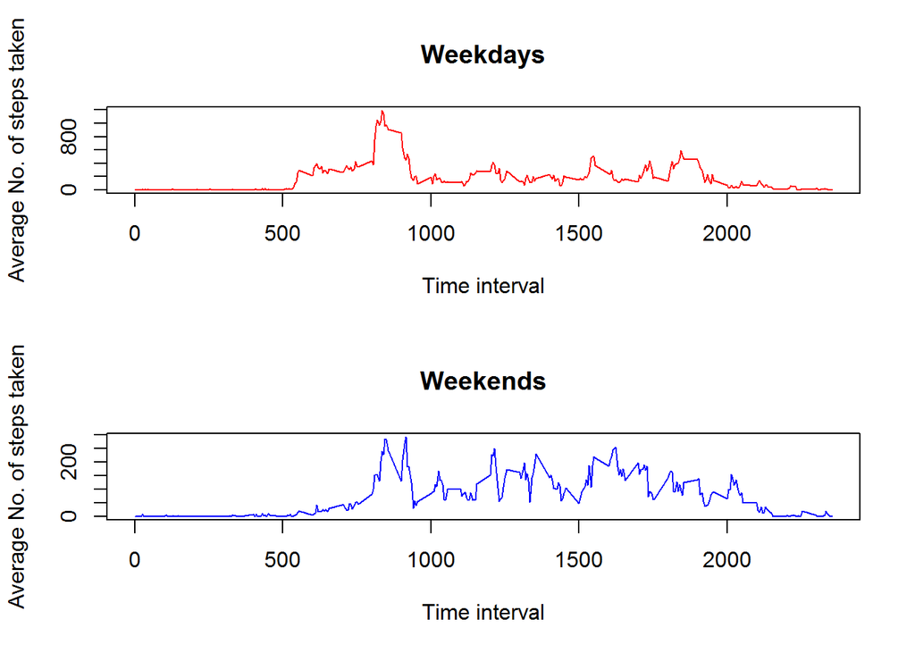

```r
##plot weekend, weekday in a panel plot
par(mfrow = c(2,1))

plot(x = weekday[,1], y = weekday[,2],
     type = "l", col = "red",
     main = "Weekdays",
     ylab = "Average No. of steps taken",
     xlab = "Time interval")

plot(x = weekend[,1], y = weekend[,2],
     type = "l", col = "blue",
     main = "Weekends",
     ylab = "Average No. of steps taken",
     xlab = "Time interval")
```